# Multi-Label Classification with Python

by [**Nosheen Altaf**](https://www.linkedin.com/in/nosheen-altaf-565158a/)

## Summary

The present [cars data](https://www.kaggle.com/abineshkumark/carsdata) is extracted from [kaggle](https://www.kaggle.com). Cars Data has Information about 3 brands/make of cars US, Japan and Europe.

We will perform data cleaning, data investigation, exploratory data analysis by creating visualizations, summary statistics, and distribution analysis etc.

Target of the data set is to find the brand/make of a car using the parameters such as horsepower, Cubic inches, Make year, etc.

A tree-based algorithm can be used to perform multi-class classification to predict the car brand.

## Get The DATA:

```python
import time
time.ctime() #for time stamp
```

```
'Sat Apr 25 12:35:01 2020'
```

```python
import pandas as pd
import numpy as np
import seaborn as sns
import matplotlib.pyplot as plt
import warnings
warnings.filterwarnings('ignore')
```

```python
df=pd.read_csv('cars.csv')
```

## Data Cleaning

Lets get familiar with our data by viewing it!

We will examine if the data is complete and if there is no null values, we will make sure that there is no inconsistency in different level of categorical variables, variable info ,variable type etc.

```python
df.head() # to view first 5 rows
```

|  | mpg | cylinders | cubicinches | hp | weightlbs | time-to-60 | year | brand |
| --- | --- | --- | --- | --- | --- | --- | --- | --- |
| 0 | 14.0 | 8 | 350 | 165 | 4209 | 12 | 1972 | US. |
| 1 | 31.9 | 4 | 89 | 71 | 1925 | 14 | 1980 | Europe. |
| 2 | 17.0 | 8 | 302 | 140 | 3449 | 11 | 1971 | US. |
| 3 | 15.0 | 8 | 400 | 150 | 3761 | 10 | 1971 | US. |
| 4 | 30.5 | 4 | 98 | 63 | 2051 | 17 | 1978 | US. |

```python
df.info() # to understand metadata info/data structure
```

```
<class 'pandas.core.frame.DataFrame'>
RangeIndex: 261 entries, 0 to 260
Data columns (total 8 columns):
mpg             261 non-null float64
 cylinders      261 non-null int64
 cubicinches    261 non-null object
 hp             261 non-null int64
 weightlbs      261 non-null object
 time-to-60     261 non-null int64
 year           261 non-null int64
 brand          261 non-null object
dtypes: float64(1), int64(4), object(3)
memory usage: 16.4+ KB
```

### Fixing Data Type and Leading and Trailing Spaces

We need to fix two things:

1:- Leading and trailing space in column headers

2:- Data type of cubicinches and weightlbs is object, we need to change data type to numeric

```python
df.columns=df.columns.str.strip() #removing spaces from column name
```

```python
df.columns
```

```
Index(['mpg', 'cylinders', 'cubicinches', 'hp', 'weightlbs', 'time-to-60',
       'year', 'brand'],
      dtype='object')
```

```python
df['cubicinches']=pd.to_numeric(df['cubicinches'],errors='coerce') #data type
```

```python
df['weightlbs']=pd.to_numeric(df['weightlbs'],errors='coerce') #data type
```

Lets check data info one more time

```python
df.info()
```

```
<class 'pandas.core.frame.DataFrame'>
RangeIndex: 261 entries, 0 to 260
Data columns (total 8 columns):
mpg            261 non-null float64
cylinders      261 non-null int64
cubicinches    259 non-null float64
hp             261 non-null int64
weightlbs      258 non-null float64
time-to-60     261 non-null int64
year           261 non-null int64
brand          261 non-null object
dtypes: float64(3), int64(4), object(1)
memory usage: 16.4+ KB
```

#### Examining Label Column...

```python
df['brand'].unique() #to see unique values in label column
```

```
array([' US.', ' Europe.', ' Japan.'], dtype=object)
```

###### we can see that leading space in data points of label column, this can be addressed by the help of following code

```python
df['brand']=df['brand'].str.strip() #removing leading and trailing space
```

## Dealing with Missing Values

We can see that cubicinches and weightlbs have missing values.It is always a good practice to impute missing values as dropping may result loss of information.

```python
df.isnull().sum()     # to check missing values
```

```
mpg            0
cylinders      0
cubicinches    2
hp             0
weightlbs      3
time-to-60     0
year           0
brand          0
dtype: int64
```

```python
len(df) #dataset length
```

```
261
```

```python
df[df.isnull()['cubicinches']==True] #to see rows with missing values
```

|  | mpg | cylinders | cubicinches | hp | weightlbs | time-to-60 | year | brand |
| --- | --- | --- | --- | --- | --- | --- | --- | --- |
| 40 | 16.0 | 6 | NaN | 105 | 3897.0 | 19 | 1976 | US. |
| 180 | 19.8 | 6 | NaN | 85 | 2990.0 | 18 | 1980 | US. |

We only have 5 missing values from 261 rows(which is less than 2%); but still for a learning perspective, lets impute those missing values...

One approach is to impute missing value by replacing overall average of quantitative variable if data is not skewed.

Lets examine the univariate distribution of Cubic (inches)

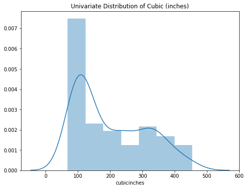

```python
plt.figure(figsize=(8,6))
sns.distplot(df['cubicinches'].dropna()).set_title("Univariate Distribution of Cubic (inches)");
```

we can see that data is not normally distributed. Now, lets see cubicinches summary statistics by brands/makes

```python
df[['brand','cubicinches']].groupby(['brand']).describe().round()
```

| brand | cubicinches count | cubicinches mean | cubicinches std | cubicinches min | cubicinches 25% | cubicinches 50% | cubicinches 75% | cubicinches max |
| --- | --- | --- | --- | --- | --- | --- | --- | --- |
| Europe. | 48.0 | 109.0 | 22.0 | 68.0 | 97.0 | 100.0 | 121.0 | 183.0 |
| Japan. | 51.0 | 104.0 | 25.0 | 70.0 | 86.0 | 97.0 | 119.0 | 168.0 |
| US. | 160.0 | 259.0 | 100.0 | 86.0 | 173.0 | 250.0 | 350.0 | 455.0 |

We can see that mean of cubicinches is very different for US brand/make. We can further visualize this by using more plots

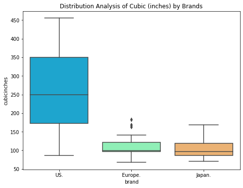

```python
plt.figure(figsize=(8,6))
sns.boxplot(x="brand",
            y="cubicinches",
            data=df,palette='rainbow').set_title('Distribution Analysis of Cubic (inches) by Brands');
```

This graph clearly shows different distribution of cubicinches for different vehicle's brands/make. We can impute missing value of cubicinches for the group mean of US brand by using following code

```python
df['cubicinches'].fillna(value=df.query("brand=='US.'")['cubicinches'].mean(),inplace=True)
```

Lets deal with the missing values of weightlbs.

```python
df[df.isnull()['weightlbs']==True] #to see rows with missing values
```

|  | mpg | cylinders | cubicinches | hp | weightlbs | time-to-60 | year | brand |
| --- | --- | --- | --- | --- | --- | --- | --- | --- |
| 14 | 19.1 | 6 | 225.0 | 90 | NaN | 19 | 1981 | US. |
| 33 | 21.0 | 6 | 199.0 | 90 | NaN | 15 | 1971 | US. |
| 172 | 29.0 | 4 | 68.0 | 49 | NaN | 20 | 1974 | Europe. |

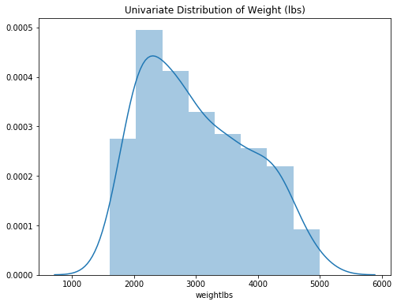

```python
plt.figure(figsize=(8,6))
sns.distplot(df['weightlbs'].dropna()).set_title("Univariate Distribution of Weight (lbs)");
```

We can see that weight is missing for two brands USA and Europe, lets examine the summary statistics of weights by brands

```python
df[['brand','weightlbs']].groupby(['brand']).describe().round()
```

| brand | weightlbs count | weightlbs mean | weightlbs std | weightlbs min | weightlbs 25% | weightlbs 50% | weightlbs 75% | weightlbs max |
| --- | --- | --- | --- | --- | --- | --- | --- | --- |
| Europe. | 47.0 | 2438.0 | 488.0 | 1825.0 | 2080.0 | 2254.0 | 2744.0 | 3820.0 |
| Japan. | 51.0 | 2229.0 | 346.0 | 1613.0 | 1980.0 | 2155.0 | 2510.0 | 2930.0 |
| US. | 160.0 | 3427.0 | 778.0 | 1800.0 | 2744.0 | 3438.0 | 4080.0 | 4997.0 |

Lets visualize distribution of weights by brands

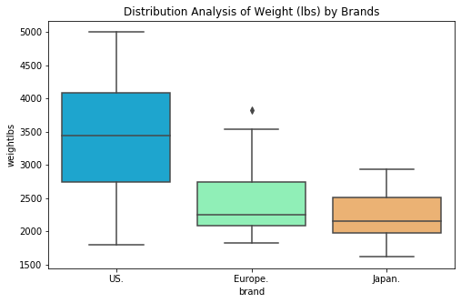

```python
plt.figure(figsize=(8,5))
sns.boxplot(x="brand",
            y="weightlbs",
            data=df,palette='rainbow').set_title('Distribution Analysis of Weight (lbs) by Brands');
```

We can see that Average weight has strong association with brands. So we can use mean of each brand to impute missing value

Lets create a function to impute missing values using brand level averages

```python
def impute_weights(cols):
    weightlbs=cols[0]
    brand=cols[1]
    if pd.isnull(weightlbs):
        if brand=='US.':
            return 3427
        else:
            return 2438
    else:
        return weightlbs
```

```python
df['weightlbs']=df[['weightlbs','brand']].apply(impute_weights,axis=1)
```

```python
df.isnull().sum()   #to check missing values
```

```
mpg            0
cylinders      0
cubicinches    0
hp             0
weightlbs      0
time-to-60     0
year           0
brand          0
dtype: int64
```

Now we have successfully imputed all missing values

## EDA

While addressing missing values, we have already examined that weightslbs and cubicinches distribution is different for each brands. Lets perform more exploratory analysis on other variables

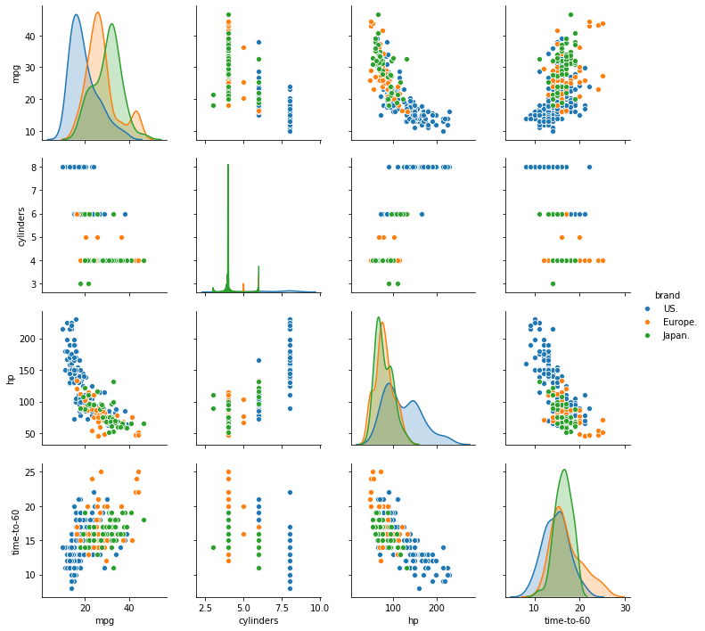

```python
sns.pairplot(df.drop(['year','weightlbs','cubicinches'],axis=1),hue='brand');
```

We can conclude following from the above pairplot visual

1:- MPG has clearly distinct density kernel for each brand.

2:- There are two highly separable Clusters. USA is very much separable from Europe and Japan, However there is quite overlapping between Europe and Japan.

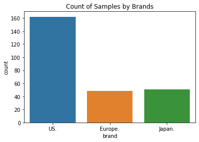

```python
sns.countplot(x='brand',data=df).set_title('Count of Samples by Brands');
```

we can see that sample proportion from USA brand is higher than Europe and Japan.

# Model Fitting

## Model Selection:

We can use Tree Methods to predict the brand of a car using given set of features. Random Forest and boosted Tree works better with bigger data.

# Data Preparation

## Train, Test Split

```python
X=df.drop('brand',axis=1)
y=df['brand']
```

```python
from sklearn.model_selection import train_test_split
```

```python
X_train, X_test, y_train, y_test = train_test_split(X, y,test_size=0.3,random_state=42)
```

## Decision Tree

Decision Trees (DTs) are a supervised learning method used for classification and regression. The goal is to create a model that predicts the value of a target variable by learning simple decision rules inferred from the data features

```python
from sklearn.tree import DecisionTreeClassifier
```

```python
dt=DecisionTreeClassifier()
```

```python
dt.fit(X_train,y_train)
```

```
DecisionTreeClassifier(class_weight=None, criterion='gini', max_depth=None,
                       max_features=None, max_leaf_nodes=None,
                       min_impurity_decrease=0.0, min_impurity_split=None,
                       min_samples_leaf=1, min_samples_split=2,
                       min_weight_fraction_leaf=0.0, presort=False,
                       random_state=None, splitter='best')
```

## Model Evaluation

```python
prediction=dt.predict(X_test)
```

```python
from sklearn.metrics import classification_report,confusion_matrix
```

```python
print(confusion_matrix(y_test,prediction))
print('\n')
print(classification_report(y_test,prediction))
```

```
[[13  0  2]
 [ 2 16  7]
 [ 0  3 36]]


              precision    recall  f1-score   support

     Europe.       0.87      0.87      0.87        15
      Japan.       0.84      0.64      0.73        25
         US.       0.80      0.92      0.86        39

    accuracy                           0.82        79
   macro avg       0.84      0.81      0.82        79
weighted avg       0.83      0.82      0.82        79
```

we can visualize the structure of the Decision Tree

```python
from IPython.display import Image
from sklearn.externals.six import StringIO
from sklearn.tree import export_graphviz
import pydot
```

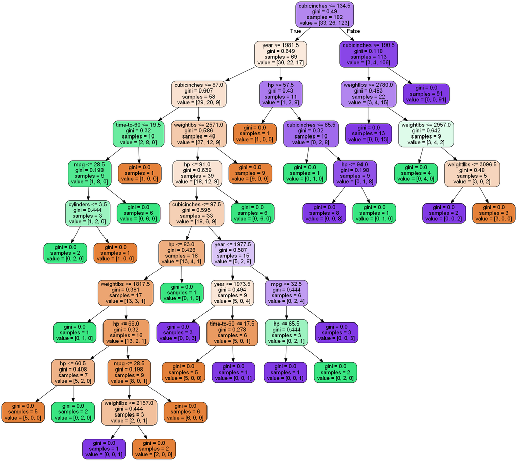

```python
features = list(df.columns[:7])
dot_data = StringIO()
export_graphviz(dt, out_file=dot_data,feature_names=features,filled=True,rounded=True)

graph = pydot.graph_from_dot_data(dot_data.getvalue())
Image(graph[0].create_png())
```

## Random Forests

Now let's compare the decision tree model with random forest model.

A Random Forest fits a number of decision tree classifiers on various sub-samples of the dataset and uses averaging to improve the predictive accuracy and control over-fitting

```python
from sklearn.ensemble import RandomForestClassifier
rfc = RandomForestClassifier(n_estimators=100)
rfc.fit(X_train, y_train)
```

```
RandomForestClassifier(bootstrap=True, class_weight=None, criterion='gini',
                       max_depth=None, max_features='auto', max_leaf_nodes=None,
                       min_impurity_decrease=0.0, min_impurity_split=None,
                       min_samples_leaf=1, min_samples_split=2,
                       min_weight_fraction_leaf=0.0, n_estimators=100,
                       n_jobs=None, oob_score=False, random_state=None,
                       verbose=0, warm_start=False)
```

```python
rfc_pred = rfc.predict(X_test)
print(confusion_matrix(y_test,rfc_pred))
print('\n')
print(classification_report(y_test,rfc_pred))
```

```
[[ 7  2  6]
 [ 3 14  8]
 [ 2  0 37]]


              precision    recall  f1-score   support

     Europe.       0.58      0.47      0.52        15
      Japan.       0.88      0.56      0.68        25
         US.       0.73      0.95      0.82        39

    accuracy                           0.73        79
   macro avg       0.73      0.66      0.67        79
weighted avg       0.75      0.73      0.72        79
```

Overall Model accuracy is 73% which is less than Decision Tree

# Conclusion

Random Forest and Boosted Tree algorithm work better for large data set with higher dimensions

We can create similar Classification/ML Models to address various business challenges that requires predictive grouping or multi classification etc.

# References:

```
1:https://www.kaggle.com/abineshkumark/carsdata
2:https://scikit-learn.org/stable/modules/tree.html
```